# Methodology - BrCa Screening

Ernesto Ulloa

September 7, 2015

The first 4 sections of this markdown file define:

- Auxiliary functions to run the analysis
- Population and detection parameters
- Effectiveness measured in DALYS
- Costs of each program

In the final section we run the cost-effectiveness analysis for all posible screening programs.

# Auxiliary functions

First we load all necessary libraries and auxiliary functions described in the *Auxiliary Functions* markdown file.

```r
library(RCurl)
library(foreign)
library(xtable)
library(knitr)
library(nlme)
library(KMsurv)
library(ggplot2)
library(plyr)
library(reshape2)

url <-'https://rawgit.com/ernesto-up/Reproducibility-Cost-Effectiveness/master/Auxiliary%20Functions/auxiliary-functions.R'
temp <- getURL(url,followlocation = TRUE, cainfo = system.file("CurlSSL", "cacert.pem", package = "RCurl"))
source(url)
```

# Population structure

In this section we load and define population data and parameters.

## Data from National Population Counsil in Mexico

We load the data from the National Population Counsil and define the age groups.

```r
url <- "https://rawgit.com/ernesto-up/Reproducibility-Cost-Effectiveness/master/Data%20Sets/Conapo-Projections.csv"
temp <- getURL(url)
conapo <- read.csv(textConnection(temp))
```

### Age Groups

Define age groups

```r
age.group.data.frame <- c('[25,40)','[40,45)','[45,50)','[50,55)','[55,60)','[60,65)','[65,70)','[70,75)')
age.group <- c(25,40,45,50,55,60,65,70,75)
```

### Mean of group age

Define the mean of each group age:

```r
mean.age.group <- data.frame(age.group = age.group.data.frame,mean.age.group = c(32.5,42.5,47.5,52.5,57.5,62.5,67.5,72.5))
```

## BrCa Incidence

We define the incidence rates by group age according to GLOBOCAN’s estimates of the incidence rates.

```r
incidence <- data.frame(age.group = age.group.data.frame,incidence = c(11.7,58.7,84.3,106.5,118.6,119.4,116.6,108.8))
```

## Estimation of BrCa letality rates by cancer stage

```r
githubURL <-'https://rawgit.com/ernesto-up/Reproducibility-Cost-Effectiveness/master/Data%20Sets/Catastrophic-Protection-Fund-Data.RData'
load(url(githubURL))
```

### Transformation of variables

We convert the time to years and separate them by clinical stage:

```r
protection.fund.data$obs.time.years <- as.numeric((protection.fund.data$tiempo.vida)/365.25)
data.by.stage <- split(protection.fund.data,protection.fund.data$etapa.clinica.2)
```

### Life tables by clinical stage

We calculate the life tables by stages:

```r
life.tables <- lapply(data.by.stage,function(x){
                            obs.time.years.redo <-floor(x$obs.time.years)
                            data.table <- data.frame(obs.time.years.redo,x$censura.vida)
                            die<-gsummary(data.table,sum,groups=obs.time.years.redo)
                            total<-gsummary(data.table, length, groups=obs.time.years.redo)
                            ltab.data<-cbind(die[,1:2], total[,2])
                            rm(obs.time.years.redo)
                            attach(ltab.data)
                            lt=length(obs.time.years.redo)
                            obs.time.years.redo[lt+1]=NA
                            nevent = x.censura.vida
                            nlost = total[,2] - x.censura.vida
                            n = nrow(x)
                            mytable <- lifetab(obs.time.years.redo, n, nlost, nevent)
                            detach(ltab.data)
                            mytable[,1:5]
                            })
```

#### Early Stage

Resulting life table for patients in early BrCa stage

|  | nsubs | nlost | nrisk | nevent | surv |
| --- | --- | --- | --- | --- | --- |
| 0-1 | 171 | 6 | 168.0 | 1 | 1.0000000 |
| 1-2 | 164 | 2 | 163.0 | 2 | 0.9940476 |
| 2-3 | 160 | 1 | 159.5 | 3 | 0.9818507 |
| 3-4 | 156 | 3 | 154.5 | 3 | 0.9633833 |
| 4-5 | 150 | 1 | 149.5 | 1 | 0.9446768 |
| 5-6 | 148 | 40 | 128.0 | 0 | 0.9383579 |

#### Locally Advanced Stage

Resulting life table for patients in locally advanced BrCa stage

|  | nsubs | nlost | nrisk | nevent | surv |
| --- | --- | --- | --- | --- | --- |
| 0-1 | 409 | 11 | 403.5 | 11 | 1.0000000 |
| 1-2 | 387 | 10 | 382.0 | 24 | 0.9727385 |
| 2-3 | 353 | 4 | 351.0 | 28 | 0.9116241 |
| 3-4 | 321 | 6 | 318.0 | 21 | 0.8389019 |
| 4-5 | 294 | 6 | 291.0 | 17 | 0.7835027 |
| 5-6 | 271 | 49 | 246.5 | 4 | 0.7377311 |

### Metastatic Stage

Resulting life table for patients for mestastasic BrCa stage

|  | nsubs | nlost | nrisk | nevent | surv |
| --- | --- | --- | --- | --- | --- |
| 0-1 | 90 | 2 | 89.0 | 28 | 1.0000000 |
| 1-2 | 60 | 5 | 57.5 | 7 | 0.6853933 |
| 2-3 | 48 | 3 | 46.5 | 9 | 0.6019541 |
| 3-4 | 36 | 4 | 34.0 | 8 | 0.4854468 |
| 4-5 | 24 | 1 | 23.5 | 5 | 0.3712241 |
| 5-6 | 18 | 2 | 17.0 | 2 | 0.2922402 |

## BrCa Null Scenario Distribution

We define the distribution of BrCa cases of patients who arrived at the National Institute of Cancer in Mexico during 2007 without screening. This is the BrCa distribution under the null scenario.

```r
distribution <- data.frame(clinical.stage = c('Early','Locally Advanced','Metastasic'),distribution = c(.344,.521,.135))
```

# Breast Cancer Screening: Detection Parameters

## Mean Sojourn Time

Mean sojourn time (Duffy & Gabe, a partir de los 40) is defined for group ages of 40-49, 50-59, 60-69, 70-74 so we extrapolate for the 25-40 group age

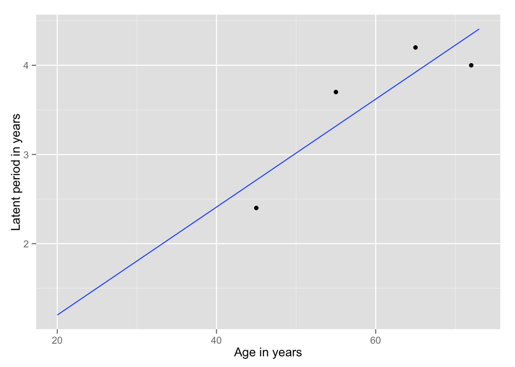

```
##        1
## 1.955879
```

Define mean sojourn time with extrapolated results:

```r
mean.sojourn.time <- data.frame(mean.sojourn.time = c(1.96,2.4,2.4,3.7,3.7,4.2,4.2,4.0),
                                age.group  = age.group.data.frame)
```

## Sensitivity of the mammogram

Sensitivity defined in (Otha et al.) is defined for the 40-49, 50-59, 60-69, 70-79 group ages, we use a linear model on the log of the sensitivity to extrapolate for the 25-40 age group.

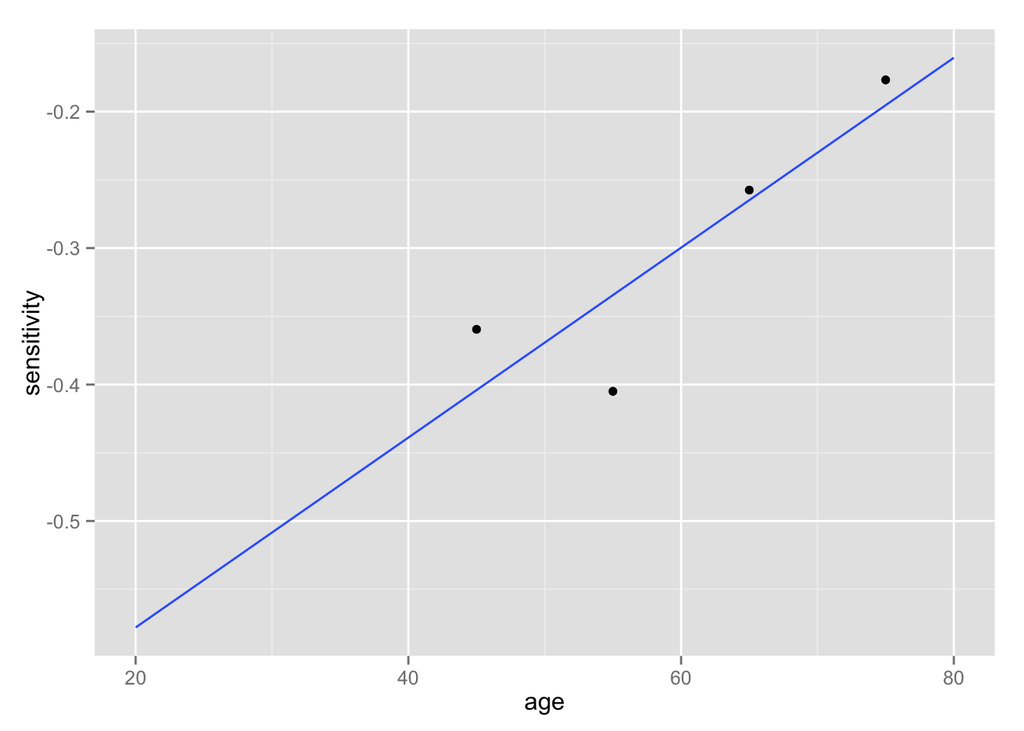

```
##         1
## 0.6119851
```

# DALYS

## Estimation of DALYS

In this section we estimate the number of DALYS lost per each stage of BrCa.

First, we define life expectacy according to the [National Institute of Statistics and Geography in Mexico](http://cuentame.inegi.org.mx/poblacion/esperanza.aspx?tema=P)

```r
life.expectancy <- 77.5
```

### DAYLS Early Stage:

```r
survival.early <- subset(survival,clinical.stage == 'Early')

YLD.early <- ddply(mean.age.group,'age.group',summarize,
                  YLD.early = 1*burden(N = 1,DW = subset(disability.weights,stage == 'Early')$disability.weights.first.year
                               ,A = mean.age.group,L = 1,a = mean.age.group) +
                    survival.early$acum.survival[1]*burden(1,
                           subset(disability.weights,stage == 'Early')$disability.weights.second.year,
                           A = mean.age.group+1,L=1,a = mean.age.group) +
                    survival.early$acum.survival[2]*burden(1,
                           subset(disability.weights,stage == 'Early')$disability.weights.second.year,
                           A = mean.age.group+2,L=1,a = mean.age.group) +
                    survival.early$acum.survival[3]*burden(1,
                           subset(disability.weights,stage == 'Early')$disability.weights.second.year,
                           A = mean.age.group+3,L=1,a = mean.age.group) +
                    survival.early$acum.survival[4]*burden(1,
                           subset(disability.weights,stage == 'Early')$disability.weights.second.year,
                           A = mean.age.group+4,L=1,a = mean.age.group) +
                    survival.early$acum.survival[5]*burden(1,
                           subset(disability.weights,stage == 'Survival')$disability.weights.second.year,
                           A = mean.age.group+5,L=life.expectancy-(mean.age.group+5),a = mean.age.group))

YLL.early <- ddply(mean.age.group,'age.group',summarize,
                      YLL.early = 0*burden(N = 1,DW =1,A = mean.age.group,L = life.expectancy - mean.age.group,a = mean.age.group) +
                        survival.early$acum.letality[1]*burden(1,DW= 1,
                               A = mean.age.group+1,L=life.expectancy-(mean.age.group+1),a = mean.age.group) +
                        survival.early$acum.letality[2]*burden(1,DW= 1,
                               A = mean.age.group+2,L=life.expectancy-(mean.age.group+2),a = mean.age.group) +
                        survival.early$acum.letality[3]*burden(1,DW= 1,
                               A = mean.age.group+3,L=life.expectancy-(mean.age.group+3),a = mean.age.group) +
                        survival.early$acum.letality[4]*burden(1,DW= 1,
                               A = mean.age.group+4,L=life.expectancy-(mean.age.group+4),a = mean.age.group) +
                        survival.early$acum.letality[5]*burden(1,DW= 1,
                               A = mean.age.group+5,L=life.expectancy-(mean.age.group+5),a = mean.age.group))
```

### DAYLS Locally Advanced:

```r
survival.locally.advanced <- subset(survival,clinical.stage == 'Locally Advanced')

YLD.locally.advanced <- ddply(mean.age.group,'age.group',summarize,
                      YLD.locally.advanced = burden(N = 1,DW =
                        subset(disability.weights,stage == 'Locally Advanced')$disability.weights.first.year,
                                   A = mean.age.group,L = 1,a = mean.age.group) +
                        survival.locally.advanced$acum.survival[1]*burden(1,
                               subset(disability.weights,stage == 'Locally Advanced')$disability.weights.second.year,
                               A = mean.age.group+1,L=1,a = mean.age.group) +
                        survival.locally.advanced$acum.survival[2]*burden(1,
                               subset(disability.weights,stage == 'Locally Advanced')$disability.weights.second.year,
                               A = mean.age.group+2,L=1,a = mean.age.group) +
                        survival.locally.advanced$acum.survival[3]*burden(1,
                               subset(disability.weights,stage == 'Locally Advanced')$disability.weights.second.year,
                               A = mean.age.group+3,L=1,a = mean.age.group) +
                        survival.locally.advanced$acum.survival[4]*burden(1,
                               subset(disability.weights,stage == 'Locally Advanced')$disability.weights.second.year,
                               A = mean.age.group+4,L=1,a = mean.age.group) +
                        survival.locally.advanced$acum.survival[5]*burden(1,
                               subset(disability.weights,stage == 'Survival')$disability.weights.second.year,
                               A = mean.age.group+5,L=life.expectancy-(mean.age.group+5),a = mean.age.group))

YLL.locally.advanced <- ddply(mean.age.group,'age.group',summarize,
                      YLL.locally.advanced = 0*burden(N = 1,DW =1,A = mean.age.group,
                        L = life.expectancy- mean.age.group,a = mean.age.group) +
                        survival.locally.advanced$acum.letality[1]*burden(1,DW= 1,
                          A = mean.age.group+1,L=life.expectancy-(mean.age.group+1),a = mean.age.group) +
                        survival.locally.advanced$acum.letality[2]*burden(1,DW= 1,
                          A = mean.age.group+2,L=life.expectancy-(mean.age.group+2),a = mean.age.group) +
                        survival.locally.advanced$acum.letality[3]*burden(1,DW= 1,
                          A = mean.age.group+3,L=life.expectancy-(mean.age.group+3),a = mean.age.group) +
                        survival.locally.advanced$acum.letality[4]*burden(1,DW= 1,
                          A = mean.age.group+4,L=life.expectancy-(mean.age.group+4),a = mean.age.group) +
                        survival.locally.advanced$acum.letality[5]*burden(1,DW= 1,
                          A = mean.age.group+5,L=life.expectancy-(mean.age.group+5),a = mean.age.group))
```

### Dalys Metastasic:

```r
survival.metastasic <- subset(survival,clinical.stage == 'Metastasic')

YLD.metastasic<- ddply(mean.age.group,'age.group',summarize,
                      YLD.metastasic = burden(N = 1,DW = subset(disability.weights,stage == 'Metastasic')$disability.weights.first.year,
                                          A = mean.age.group,L = 1,a = mean.age.group) +
                                            survival.metastasic$acum.survival[1]*burden(1,
                                              subset(disability.weights,stage == 'Metastasic')$disability.weights.second.year,
                                          A = mean.age.group+1,L=1,a = mean.age.group) +
                                            survival.metastasic$acum.survival[2]*burden(1,
                                              subset(disability.weights,stage == 'Metastasic')$disability.weights.second.year,
                                          A = mean.age.group+2,L=1,a = mean.age.group) +
                                            survival.metastasic$acum.survival[3]*burden(1,
                                              subset(disability.weights,stage == 'Metastasic')$disability.weights.second.year,
                                          A = mean.age.group+3,L=1,a = mean.age.group) +
                                            survival.metastasic$acum.survival[4]*burden(1,
                                              subset(disability.weights,stage == 'Metastasic')$disability.weights.second.year,
                                          A = mean.age.group+4,L=1,a = mean.age.group) +
                                            survival.metastasic$acum.survival[5]*burden(1,
                                              subset(disability.weights,stage == 'Survival')$disability.weights.second.year,
                                          A = mean.age.group+5,L=life.expectancy-(mean.age.group+5),a = mean.age.group))

YLL.metastasic <- ddply(mean.age.group,'age.group',summarize,
                                 YLL.metastasic = 0*burden(N = 1,DW =1,A = mean.age.group,
                                    L = life.expectancy- mean.age.group,a = mean.age.group) +
                                      survival.metastasic$acum.letality[1]*burden(1,DW= 1,
                                    A = mean.age.group+1,L=life.expectancy-(mean.age.group+1),a = mean.age.group) +
                                      survival.metastasic$acum.letality[2]*burden(1,DW= 1,
                                    A = mean.age.group+2,L=life.expectancy-(mean.age.group+2),a = mean.age.group) +
                                      survival.metastasic$acum.letality[3]*burden(1,DW= 1,
                                    A = mean.age.group+3,L=life.expectancy-(mean.age.group+3),a = mean.age.group) +
                                      survival.metastasic$acum.letality[4]*burden(1,DW= 1,
                                    A = mean.age.group+4,L=life.expectancy-(mean.age.group+4),a = mean.age.group) +
                                     survival.metastasic$acum.letality[5]*burden(1,DW= 1,
                                    A = mean.age.group+5,L=life.expectancy-(mean.age.group+5),a = mean.age.group))


total.DALY.early <- data.frame(age.group = YLD.early$age.group,
                                  total.DALY.early  = YLD.early$YLD.early + YLL.early$YLL.early)

total.DALY.advanced <- data.frame(age.group = YLD.locally.advanced$age.group,
                            total.DALY.advanced = YLD.locally.advanced$YLD.locally.advanced +
                            YLL.locally.advanced$YLL.locally.advanced)

total.DALY.metastasic <-  data.frame(age.group = YLD.metastasic$age.group,
                                total.DALY.metastasic  = YLD.metastasic$YLD.metastasic+
                                YLL.metastasic$YLL.metastasic)


DALY <- merge(total.DALY.early,total.DALY.advanced)
DALY <- merge(DALY,total.DALY.metastasic)
```

```r
print(DALY)
```

```
##   age.group total.DALY.early total.DALY.advanced total.DALY.metastasic
## 1   [25,40)         5.523548           13.839577             23.423744
## 2   [40,45)         4.855410           12.051324             20.457937
## 3   [45,50)         4.438221           10.934732             18.606073
## 4   [50,55)         3.953518            9.637436             16.454515
## 5   [55,60)         3.390372            8.130194             13.954760
## 6   [60,65)         2.736091            6.379029             11.050460
## 7   [65,70)         1.975924            4.344464              7.676145
## 8   [70,75)         1.092736            1.980638              3.755750
```

# Costs of Screening and Treatment

## Mexican GDP

# Cost Effectiveness Analysis

## Calculamos casos nuevos con tasas de GLOBOCAN y base de CONAPO:

```r
conapo.incidence <- population.incidence(incidence,age.group,conapo,mean.age.group)
conapo.incidence <- merge(conapo.incidence,DALY)
conapo.incidence <- merge(conapo.incidence,costs,id = 'period')
```

# Cost Effectiveness Analysis

In this last section we run the simulations to obtain the cost effectiveness estimates for all the screening programs. First we load the data.

```r
library(plyr)
library(reshape2)
library(ggplot2)
```

Define all the screening percentages for each age group:

```r
porc.25.40 <- seq(0,2,1)*.01
porc.40.45 <- seq(0,15,5)*.01
porc.45.50 <- seq(0,18,6)*.01
porc.50.55 <- seq(0,20,5)*.01
porc.55.60 <- seq(0,25,5)*.01
porc.60.65 <- seq(0,20,5)*.01
porc.65.70 <- seq(0,18,6)*.01
porc.70.75 <- seq(0,2,2)*.01
```

Define periodicities of the programs:

```r
periodicity<- c(1,2,3)
```

Starting and end year:

```r
start<- 2016
end <- 2026
```

We create a data frame with all the information for each intervention and run the simulations. Results are stored in the same data frame and saved. This last part of the markdown file is not evaluated. To load the results, see the **Data** section of the github page.

It takes approximately 20 minutes to run with:

MacBook Pro 2.9 GHz Intel Core i5 8 GB 1867 MHz DDR3 R version 3.2.0 (2015-04-16)

```r
 results.simulation <- data.frame(expand.grid(list = list(periodicity = periodicity,porc.25.40 = porc.25.40, porc.40.45 = porc.40.45,
                        porc.45.50 = porc.45.50, porc.50.55 = porc.50.55, porc.55.60 = porc.55.60,
                        porc.60.65 = porc.60.65, porc.65.70 = porc.65.70, porc.70.75 = porc.70.75)), total.dalys = 0,
                        total.cost.masto = 0, total.treatment = 0, total.cost = 0)

for(i in 1:dim(results.simulation)[1])
{
  percentage <- data.frame(percentage = as.numeric(results.simulation[i,2:9]),age.group=age.group.data.frame)
  periodicity <- as.numeric(results.simulation[i,'periodicity'])
  results <- resume.ce(percentage,periodicity,incidence,conapo.incidence,mean.sojourn.time,sensitivity,
                        start,end,age.group.data.frame)
  results.simulation[i,10:13] <- results
}

rm(list = setdiff(ls(),'results.simulation'))
```